# Portfolio

Youri Lam

2022-11-20

Assignment 1.1

```r
dataset_Elegans <- read_excel("~/School/Jaar 4/Workflows/CE.LIQ.FLOW.062_Tidydata.xlsx")
typeof(dataset_Elegans$RawData)
```

```
## [1] "double"
```

```r
typeof(dataset_Elegans$compName)
```

```
## [1] "character"
```

```r
typeof(dataset_Elegans$compConcentration)
```

```
## [1] "character"
```

The variables RawData (the outcome - number of offspring counted as an integer value, after incubation time), compName (the generic name of the compound/chemical) and the compConcentration (the concentration of the compound) are all very important in this research.Judging from the experimental description above, I would expect the datatype of the RawData to be integer,compConcentration should be double and the datatype of compName should be character.Judging by the fact that none of these have the correct datatype except compName, I can safely assume the data has not been correctly imported into R.

```r
class(dataset_Elegans$RawData) = "integer"
class(dataset_Elegans$compConcentration) = "double"
```

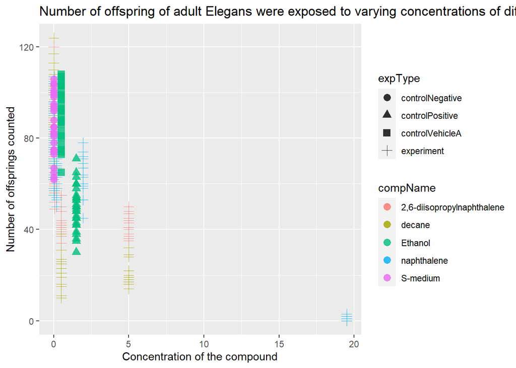

```r
class(dataset_Elegans$compName) = "character"

ggplot(data = dataset_Elegans, aes(x = compConcentration, y = RawData)) +
  geom_point(aes(color = compName,
                 shape = expType),
             size = 3,alpha = 0.8) +
  labs(title = "Number of offspring of adult Elegans were exposed to varying concentrations of different compounds",
       x = "Concentration of the compound",
       y = "Number of offsprings counted")
```

Because of the concentration levels being so incredibly low, everything is super close together.

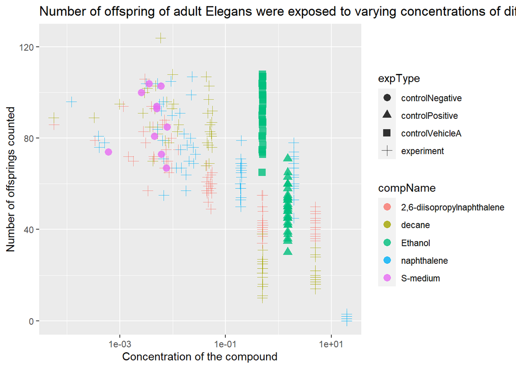

```r
dataset_Elegans$compConcentration <- jitter(dataset_Elegans$compConcentration, 2)

ggplot(data = dataset_Elegans, aes(x = compConcentration, y = RawData)) +
  geom_point(aes(color = compName,
                 shape = expType),
             size = 3,alpha = 0.8) +
  scale_x_continuous(trans='log10') +
  labs(title = "Number of offspring of adult Elegans were exposed to varying concentrations of different compounds",
       x = "Concentration of the compound",
       y = "Number of offsprings counted")
```

Think about how you would analyze this experiment to learn whether there is indeed an effect of different concentrations on offspring count and whether the different compounds have a different curve (IC50). Write down you analysis as a step-wise plan.